# **Amygdala-LPFC rsFC does not predict test anxiety scores in late adolescence - RMarkdown**

# **3. Using Shapiro-Wilk to test the normality of the data**

```r
#TASC is Not Normally Distributed
shapiro.test(Hierarchical$TASC)
```

```
##
##  Shapiro-Wilk normality test
##
## data:  Hierarchical$TASC
## W = 0.96209, p-value = 0.01704
```

```r
#MatrixReasoning is Not Normally Distributed
shapiro.test(Hierarchical$MatrixReasoning)
```

```
##
##  Shapiro-Wilk normality test
##
## data:  Hierarchical$MatrixReasoning
## W = 0.95204, p-value = 0.004211
```

```r
#Amygdala_LPFC is Normally distributed
shapiro.test(Hierarchical$Amygdala_LPFC)
```

```
##
##  Shapiro-Wilk normality test
##
## data:  Hierarchical$Amygdala_LPFC
## W = 0.98494, p-value = 0.4622
```

```r
#JPL.Amygdala is Not Normally Distributed
shapiro.test(Hierarchical$JLC.Amygdala)
```

```
##
##  Shapiro-Wilk normality test
##
## data:  Hierarchical$JLC.Amygdala
## W = 0.95436, p-value = 0.005765
```

```r
#Pallidum.LPFC is Normally Distributed
shapiro.test(Hierarchical$Pallidum.LPFC)
```

```
##
##  Shapiro-Wilk normality test
##
## data:  Hierarchical$Pallidum.LPFC
## W = 0.99045, p-value = 0.8166
```

TASC, JLC and MR were not normally distributed. As TASC and RM contain only positive values, a BoxCox transformation can be used to normalise the data. As JLC contains both positive and negative values, a Yeo-Johnson transformation can be used to normalise the data.

# **4. Attempting to transform TASC and MR using BoxCox**

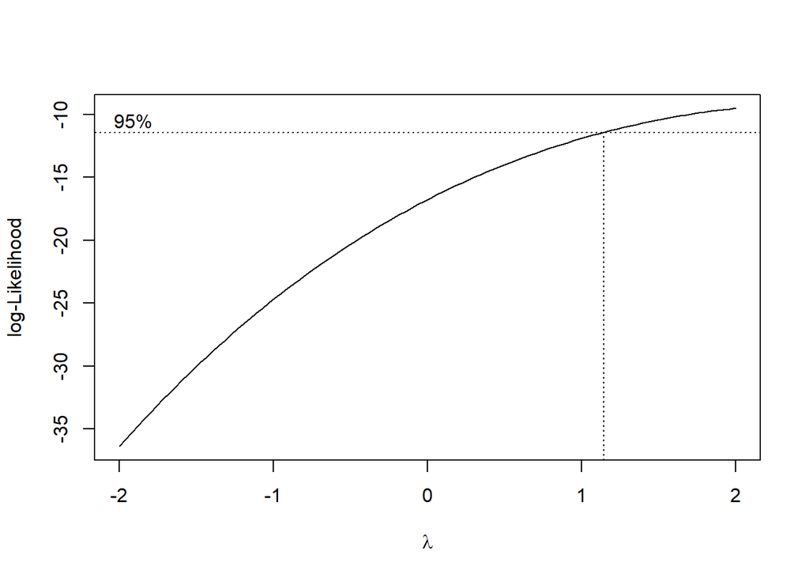

```r
#Test +ive
#MatrixReasoning Transformation of MR - BoxCox
MR1 <- boxcox(lm(Hierarchical$MatrixReasoning ~ 1))
```

```r
MRnd <- (Hierarchical$MatrixReasoning^3)
shapiro.test(MRnd) #Normally Distributed
```

```
##
##  Shapiro-Wilk normality test
##
## data:  MRnd
## W = 0.9712, p-value = 0.06464
```

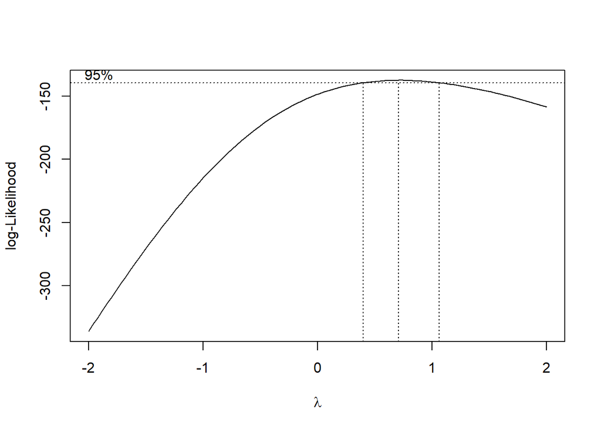

```r
TASC1 <- boxcox(lm(Hierarchical$TASC ~ 1))
```

```r
TASCnd <- sqrt(Hierarchical$TASC)
shapiro.test(TASCnd) #Not Normally Distributed
```

```
##
##  Shapiro-Wilk normality test
##
## data:  TASCnd
## W = 0.96033, p-value = 0.01326
```

MR had a lambda>2 and was transformed to normality by cubing. TASC had a lambda of 0.5-1 and could not be transformed.

# **5. Attempting to transform JLC using Yeo-Johnson transformation**

```r
#Test -ive/+ive
#Transformation of JLC - Yeo-Johnson
JLCtrans <- yjPower(Hierarchical$JLC.Amygdala, lambda = -1)
shapiro.test(JLCtrans)
```

```
##
##  Shapiro-Wilk normality test
##
## data:  JLCtrans
## W = 0.97313, p-value = 0.08626
```

# **6. The Restricted Model:**

TASC was not normally distributed and could not be transformed to normality using BoxCox transformation. Therefore, the parametric assumptions were not met, and we must use Spearman’s Rank and Kruskal-Wallis comparison to complete a Non-Parametric quasi hierarchical regression analysis.

```r
#Restricted Model
SR1 <- cor.test(Hierarchical$TASC, Hierarchical$MatrixReasoning, method = "spearman", exact = F)
SR1 #Sig
```

```
##
##  Spearman's rank correlation rho
##
## data:  Hierarchical$TASC and Hierarchical$MatrixReasoning
## S = 116764, p-value = 0.003761
## alternative hypothesis: true rho is not equal to 0
## sample estimates:
##        rho
## -0.3184678
```

**Plot of the restricted model correlation:**

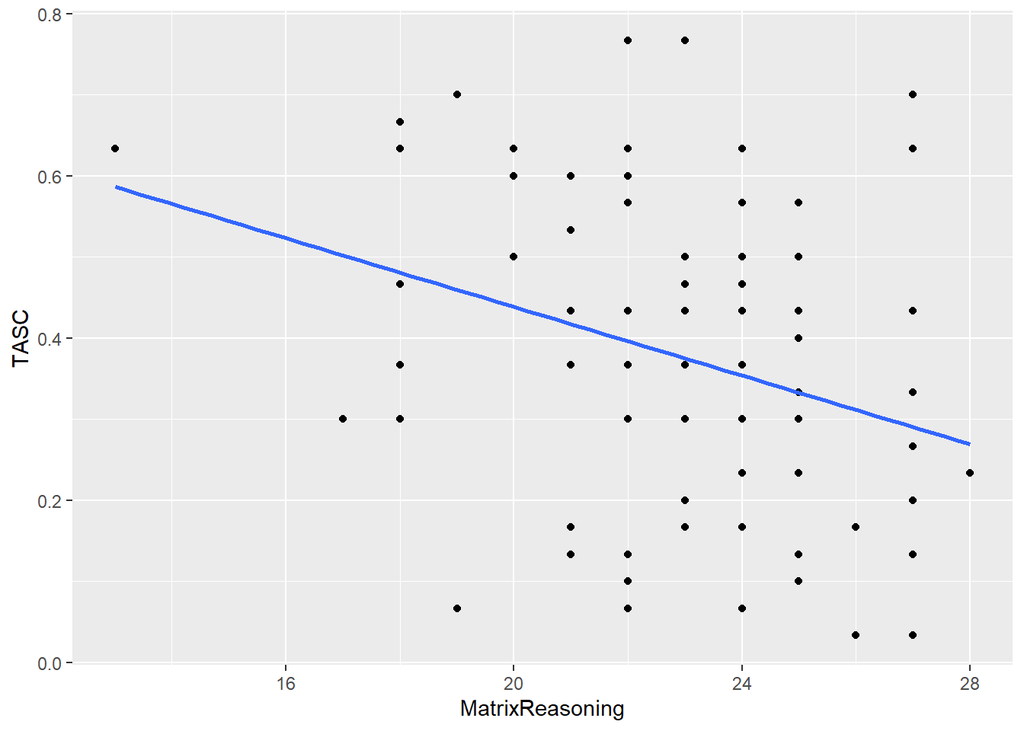

```r
SR1df <- data.frame(MatrixReasoning = Hierarchical$MatrixReasoning,
                 TASC = Hierarchical$TASC)
ggplot(SR1df, aes(x = MatrixReasoning, y = TASC)) +
  geom_point() +
  geom_smooth(method = "lm", se = FALSE)
```

# **7. Spearman’s Rank correlations of the three unrestricted models**

```r
#Unrestricted Amy-LPF model
SR2 <- cor.test(Hierarchical$TASC, Hierarchical$MatrixReasoning + Hierarchical$Amygdala_LPFC, method = "spearman", exact = F)
#Unrestricted GP-LPFC model
SR3 <- cor.test(Hierarchical$TASC, Hierarchical$MatrixReasoning + Hierarchical$Pallidum.LPFC, method = "spearman", exact = F)
#Unrestricted Amy-JPL model
SR4 <- cor.test(Hierarchical$TASC, Hierarchical$MatrixReasoning + Hierarchical$JLC.Amygdala, method = "spearman", exact = F)
SR2 #Sig
```

```
##
##  Spearman's rank correlation rho
##
## data:  Hierarchical$TASC and Hierarchical$MatrixReasoning + Hierarchical$Amygdala_LPFC
## S = 117464, p-value = 0.002943
## alternative hypothesis: true rho is not equal to 0
## sample estimates:
##        rho
## -0.3263759
```

```r
SR3 #Sig
```

```
##
##  Spearman's rank correlation rho
##
## data:  Hierarchical$TASC and Hierarchical$MatrixReasoning + Hierarchical$Pallidum.LPFC
## S = 117101, p-value = 0.003345
## alternative hypothesis: true rho is not equal to 0
## sample estimates:
##        rho
## -0.3222738
```

```r
SR4 #Sig
```

```
##
##  Spearman's rank correlation rho
##
## data:  Hierarchical$TASC and Hierarchical$MatrixReasoning + Hierarchical$JLC.Amygdala
## S = 118469, p-value = 0.002046
## alternative hypothesis: true rho is not equal to 0
## sample estimates:
##        rho
## -0.3377302
```

# **8. Comparing the models using Kruskal-Wallis**

```r
#Test comparison
kruskal.test(list(SR1 = SR1$estimate, SR2 = SR2$estimate)) #NS
```

```
##
##  Kruskal-Wallis rank sum test
##
## data:  list(SR1 = SR1$estimate, SR2 = SR2$estimate)
## Kruskal-Wallis chi-squared = 1, df = 1, p-value = 0.3173
```

```r
#GP control comparison
kruskal.test(list(SR1 = SR1$estimate, SR3 = SR3$estimate)) #NS
```

```
##
##  Kruskal-Wallis rank sum test
##
## data:  list(SR1 = SR1$estimate, SR3 = SR3$estimate)
## Kruskal-Wallis chi-squared = 1, df = 1, p-value = 0.3173
```

```r
#JPL control comparison
kruskal.test(list(SR1 = SR1$estimate, SR4 = SR4$estimate)) #NS
```

```
##
##  Kruskal-Wallis rank sum test
##
## data:  list(SR1 = SR1$estimate, SR4 = SR4$estimate)
## Kruskal-Wallis chi-squared = 1, df = 1, p-value = 0.3173
```

All correlations were statistically significant, but the unrestricted models were not significantly better predictors of TASC than the restricted model, suggesting that amygdala-LPFC does not explain variance in TASC beyond MR.

# **Post-Hoc exploratory analyses**

```r
PH5 <- cor.test(Hierarchical$TASC, Hierarchical$Amygdala_LPFC, method = "spearman", exact = F) #Post-Hoc
PH5 #NS
```

```
##
##  Spearman's rank correlation rho
##
## data:  Hierarchical$TASC and Hierarchical$Amygdala_LPFC
## S = 98805, p-value = 0.3037
## alternative hypothesis: true rho is not equal to 0
## sample estimates:
##        rho
## -0.1156854
```

```r
PEARSON1 <- cor.test(Hierarchical$Amygdala_LPFC, MRnd, corr.method = "pearson")
PEARSON1 #MRnd and Amygdala_LPFC do not correlate
```

```
##
##  Pearson's product-moment correlation
##
## data:  Hierarchical$Amygdala_LPFC and MRnd
## t = 1.563, df = 79, p-value = 0.1221
## alternative hypothesis: true correlation is not equal to 0
## 95 percent confidence interval:
##  -0.04693305  0.37727354
## sample estimates:
##       cor
## 0.1731912
```

TASC and Amygdala-LPFC do not directly correlate with Spearman’s correlation. Transformed MR and Amygdala-LPFC do not correlate with Pearson’s correlation.